# Curs d’introducció a R

Classe 3: Estadística bàsica

Eudald Correig i Fraga

17 de de juliol de 2025

# Què és l’estadística

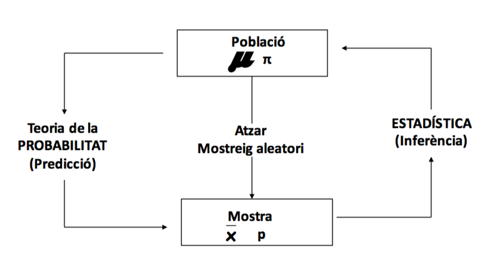

Probabilitat i estadística

# Estadística descriptiva

## Introducció

- Variables contínues:
  - mean()
  - sd()
  - range()
  - median()
- Variables categòriques o de text:
  - table()
- Tot a la vegada
  - summary()

Descriptius: variables contínues

```r
# Mitjana:
mean(dades$edat)
```

```
## [1] 77.5
```

```r
# Desviació estàndard:
sd(dades$imc)
```

```
## [1] 3.441606
```

```r
# Rang:
range(dades$pes)
```

```
## [1] 66.09842 94.53945
```

```r
# Mediana:
median(dades$alcada)
```

[output not shown]

```r
quantile(dades$pes)
```

```
##       0%      25%      50%      75%     100%
## 66.09842 73.50695 79.88907 81.60256 94.53945
```

Descriptius: variables categòriques

```r
table(dades$sexe)
```

```
##
## D M
## 5 5
```

```r
table(dades$sexe, dades$curacio)
```

```
##
##     FALSE TRUE
##   D     0    5
##   M     5    0
```

Descriptius: funció summary()

```r
summary(dades)
```

```
##        id            sexe               normal         curacio
##  Min.   : 1.00   Length:10          Min.   :-1.6813   Mode :logical
##  1st Qu.: 3.25   Class :character   1st Qu.:-0.5700   FALSE:5
##  Median : 5.50   Mode  :character   Median : 0.5091   TRUE :5
##  Mean   : 5.50                      Mean   : 0.1194
##  3rd Qu.: 7.75                      3rd Qu.: 0.6295
##  Max.   :10.00                      Max.   : 1.4260
##       edat           alçada           pes             imc               imccat
##  Min.   :56.00   Min.   :154.5   Min.   :66.10   Min.   :23.61   Sobrepès  :6
##  1st Qu.:67.25   1st Qu.:160.4   1st Qu.:73.51   1st Qu.:27.01   Pes normal:1
##  Median :80.00   Median :165.5   Median :79.89   Median :28.94   Obesitat  :3
##  Mean   :77.50   Mean   :165.8   Mean   :79.68   Mean   :29.05
##  3rd Qu.:88.25   3rd Qu.:170.1   3rd Qu.:81.60   3rd Qu.:31.59
##  Max.   :92.00   Max.   :178.2   Max.   :94.54   Max.   :34.43
```

- També es pot fer summary de només una o algunes variables:

```r
summary(dades$edat)
```

```
##    Min. 1st Qu.  Median    Mean 3rd Qu.    Max.
##   56.00   67.25   80.00   77.50   88.25   92.00
```

```r
# Versió tidyverse amb select
dades |>
  select(sexe, edat, alçada) |>
  summary()
```

```
##      sexe                edat           alçada
##  Length:10          Min.   :56.00   Min.   :154.5
##  Class :character   1st Qu.:67.25   1st Qu.:160.4
##  Mode  :character   Median :80.00   Median :165.5
##                     Mean   :77.50   Mean   :165.8
##                     3rd Qu.:88.25   3rd Qu.:170.1
##                     Max.   :92.00   Max.   :178.2
```

# Intervals de confiança

## El Teorema Central del Límit

El **Teorema Central del Límit (TCL)** és un dels resultats més importants de l’estadística. Ens diu que:

> Si agafem mostres aleatòries d’una població (independentment de la seva distribució original), la distribució de les mitjanes d’aquestes mostres tendeix a una distribució normal quan la mida de la mostra és gran.

### Simulació del Teorema Central del Límit

Per veure com funciona el TCL, podem utilitzar una simulació interactiva:

```r
# Executar la simulació del TCL
source("central_limit_theorem.R")
```